# Phase 3a — An Interpretable Model: Logistic Regression

Zohair Khan

2026-07-07

## Purpose

The HR director needs two different things from a model: **explanations** (which factors move the odds of leaving, by how much) and **predictions** (who is most at risk). This phase builds the explanation model — logistic regression, the workhorse for exactly this reason: every coefficient converts to an odds ratio a non-statistician can act on. Phase 3b (Python) builds the prediction model; Phase 3c compares them honestly on the same held-out test set.

## The shared train/test split

Both models must be judged on the **same** unseen employees, or the comparison is meaningless. The split — stratified 80/20 on attrition, seed 42 — was created once and committed to `data/train-test-split.csv`, keyed on `EmployeeNumber`. If that file exists, this chunk **reads it rather than regenerating it**, so partially re-running the pipeline can never silently put R and Python on different splits. Delete the file to regenerate from seed. The Python notebook reads the same file; it never re-splits.

```r
hr <- read_csv("data/hr-attrition.csv", show_col_types = FALSE)

if (file.exists("data/train-test-split.csv")) {
  split <- read_csv("data/train-test-split.csv", show_col_types = FALSE)
} else {
  split <- hr %>%
    group_by(Attrition) %>%
    mutate(set = if_else(row_number() %in%
                           sample(n(), size = round(0.8 * n())),
                         "train", "test")) %>%
    ungroup() %>%
    select(EmployeeNumber, set)
  write_csv(split, "data/train-test-split.csv")
}

split %>%
  left_join(hr %>% select(EmployeeNumber, Attrition), by = "EmployeeNumber") %>%
  group_by(set) %>%
  summarise(n = n(), attrition_rate = mean(Attrition == "Yes"))
```

```
## # A tibble: 2 × 3
##   set       n attrition_rate
##   <chr> <int>          <dbl>
## 1 test    294          0.160
## 2 train  1176          0.162
```

Stratification check: train and test attrition rates should sit within a point of each other — they do.

## Feature preparation

Choices, stated explicitly:

- Drop the constants (`EmployeeCount`, `StandardHours`, `Over18`) and the ID (`EmployeeNumber`, kept aside as the key).
- Nominal variables become factors; 1–4/1–5 ordinal ratings stay numeric (one slope per rating step — same simplification as Phase 2).
- `MonthlyIncome` is rescaled to thousands so its odds ratio reads “per $1,000/month,” not “per dollar.”
- Everything goes in. The tenure family (`YearsAtCompany`, `TotalWorkingYears`, …, and `JobLevel`~`MonthlyIncome`, r≈0.95) is collinear, which widens confidence intervals on individual coefficients but does not bias predictions. We read individual coefficients with that caveat and lean on Phase 2’s univariate tests as the cross-check.

```r
model_df <- hr %>%
  select(-EmployeeCount, -StandardHours, -Over18) %>%
  mutate(
    Attrition = factor(Attrition, levels = c("No", "Yes")),
    MonthlyIncome = MonthlyIncome / 1000,
    across(where(is.character), as.factor)
  ) %>%
  left_join(split, by = "EmployeeNumber")

train <- model_df %>% filter(set == "train") %>% select(-set, -EmployeeNumber)
test  <- model_df %>% filter(set == "test")  %>% select(-set, -EmployeeNumber)

dim(train); dim(test)
```

```
## [1] 1176   31
```

```
## [1] 294  31
```

## Fit

```r
logreg <- glm(Attrition ~ ., data = train, family = binomial())
```

## Odds ratios — what moves the needle

```r
odds <- tidy(logreg, exponentiate = TRUE, conf.int = TRUE) %>%
  filter(term != "(Intercept)") %>%
  arrange(desc(abs(log(estimate)))) %>%
  select(term, odds_ratio = estimate,
         ci_low = conf.low, ci_high = conf.high, p_value = p.value)
```

[output not shown]

[output not shown]

[output not shown]

[output cut: 18 more lines]

[output not shown]

[output not shown]

[output cut: 85 more lines]

[output not shown]

```r
write_csv(odds, "outputs/logreg-odds-ratios.csv")

odds %>%
  filter(p_value < 0.05) %>%
  mutate(across(c(odds_ratio, ci_low, ci_high), ~round(., 2)),
         p_value = format.pval(p_value, digits = 2)) %>%
  kable(caption = "Statistically significant coefficients, sorted by strength (odds ratios; >1 raises attrition odds, <1 lowers)")
```

Statistically significant coefficients, sorted by strength (odds ratios; >1 raises attrition odds, <1 lowers)

| term | odds_ratio | ci_low | ci_high | p_value |
| --- | --- | --- | --- | --- |
| JobRoleSales Representative | 18.58 | 1.35 | 518.20 | 0.03977 |
| BusinessTravelTravel_Frequently | 6.17 | 2.58 | 16.28 | 9.8e-05 |
| OverTimeYes | 5.86 | 3.86 | 9.01 | 2.4e-16 |
| JobRoleLaboratory Technician | 5.02 | 1.82 | 15.43 | 0.00289 |
| BusinessTravelTravel_Rarely | 2.50 | 1.13 | 6.16 | 0.03337 |
| MaritalStatusSingle | 2.34 | 1.10 | 5.10 | 0.02935 |
| JobInvolvement | 0.57 | 0.43 | 0.74 | 4.0e-05 |
| WorkLifeBalance | 0.59 | 0.45 | 0.78 | 0.00017 |
| EnvironmentSatisfaction | 0.64 | 0.53 | 0.77 | 1.8e-06 |
| JobSatisfaction | 0.66 | 0.55 | 0.79 | 4.3e-06 |
| RelationshipSatisfaction | 0.81 | 0.67 | 0.97 | 0.02107 |
| NumCompaniesWorked | 1.23 | 1.13 | 1.34 | 2.4e-06 |
| YearsSinceLastPromotion | 1.21 | 1.10 | 1.33 | 6.8e-05 |
| TrainingTimesLastYear | 0.83 | 0.71 | 0.98 | 0.02824 |
| YearsInCurrentRole | 0.89 | 0.80 | 0.98 | 0.02312 |
| YearsWithCurrManager | 0.90 | 0.81 | 0.99 | 0.03541 |
| TotalWorkingYears | 0.92 | 0.86 | 0.98 | 0.01594 |
| DistanceFromHome | 1.04 | 1.01 | 1.06 | 0.00226 |

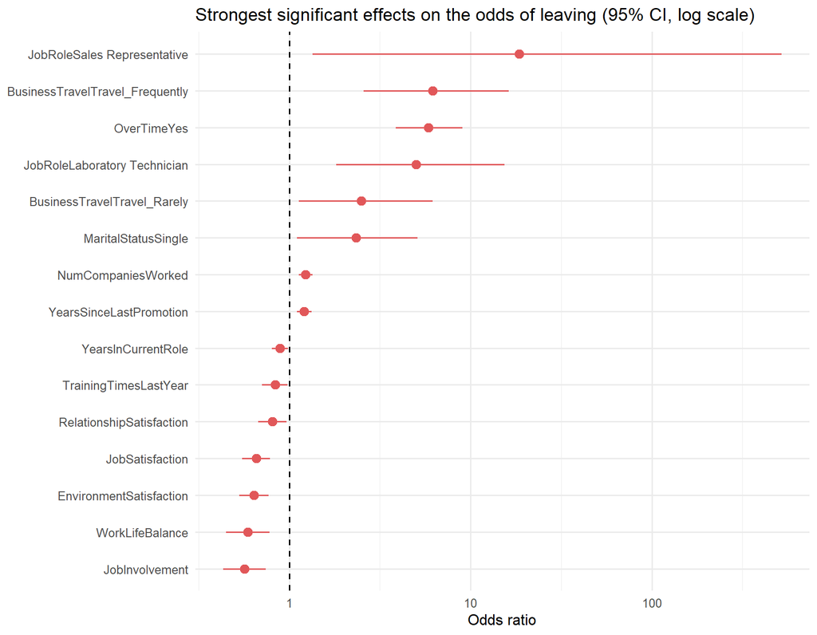

```r
odds %>%
  filter(p_value < 0.05) %>%
  slice_head(n = 15) %>%
  ggplot(aes(x = reorder(term, log(odds_ratio)), y = odds_ratio)) +
  geom_pointrange(aes(ymin = ci_low, ymax = ci_high), color = "#e15759") +
  geom_hline(yintercept = 1, linetype = "dashed") +
  scale_y_log10() +
  coord_flip() +
  labs(title = "Strongest significant effects on the odds of leaving (95% CI, log scale)",
       x = NULL, y = "Odds ratio")
```

### Stability check: do the headline odds ratios survive dropping the redundant fields?

The model contains two nested/redundant pairs — `JobLevel` ≈ `MonthlyIncome` (r ≈ 0.95) and `Department` ⊂ `JobRole` — which is exactly where “holding everything else constant” gets fragile. The cheap robustness test: refit without `JobLevel` and `Department` and compare the coefficients we actually interpret in the memo.

```r
logreg_slim <- glm(Attrition ~ . - JobLevel - Department,
                   data = train, family = binomial())

headline_terms <- c("OverTimeYes", "BusinessTravelTravel_Frequently",
                    "JobRoleSales Representative", "MaritalStatusSingle",
                    "MonthlyIncome", "JobSatisfaction", "WorkLifeBalance",
                    "YearsSinceLastPromotion")

bind_rows(
  tidy(logreg,      exponentiate = TRUE) %>% mutate(model = "full"),
  tidy(logreg_slim, exponentiate = TRUE) %>% mutate(model = "no JobLevel/Department")
) %>%
  filter(term %in% headline_terms) %>%
  select(term, model, odds_ratio = estimate, p_value = p.value) %>%
  pivot_wider(names_from = model, values_from = c(odds_ratio, p_value)) %>%
  mutate(across(where(is.numeric), ~round(., 3))) %>%
  kable(caption = "Memo-interpreted odds ratios, full model vs redundant-fields-removed")
```

Memo-interpreted odds ratios, full model vs redundant-fields-removed

| term | odds_ratio_full | odds_ratio_no JobLevel/Department | p_value_full | p_value_no JobLevel/Department |
| --- | --- | --- | --- | --- |
| BusinessTravelTravel_Frequently | 6.169 | 6.074 | 0.000 | 0.000 |
| JobRoleSales Representative | 18.585 | 6.555 | 0.040 | 0.002 |
| JobSatisfaction | 0.658 | 0.658 | 0.000 | 0.000 |
| MaritalStatusSingle | 2.342 | 2.312 | 0.029 | 0.031 |
| MonthlyIncome | 0.978 | 1.016 | 0.809 | 0.816 |
| OverTimeYes | 5.862 | 5.873 | 0.000 | 0.000 |
| WorkLifeBalance | 0.591 | 0.597 | 0.000 | 0.000 |
| YearsSinceLastPromotion | 1.207 | 1.210 | 0.000 | 0.000 |

## Held-out performance

```r
test_prob <- predict(logreg, newdata = test, type = "response")
test_actual <- as.integer(test$Attrition == "Yes")

roc_obj <- roc(test_actual, test_prob, quiet = TRUE)
auc_val <- as.numeric(auc(roc_obj))
brier <- mean((test_prob - test_actual)^2)

pred_class <- as.integer(test_prob >= 0.5)
cm <- table(actual = test_actual, predicted = pred_class)
cm
```

```
##       predicted
## actual   0   1
##      0 243   4
##      1  25  22
```

```r
accuracy   <- sum(diag(cm)) / sum(cm)
precision  <- cm["1", "1"] / sum(cm[, "1"])
recall     <- cm["1", "1"] / sum(cm["1", ])

# Top-decile lift: of the 10% of test employees the model rates riskiest,
# what share of all actual leavers do they contain, vs the 10% random baseline?
decile_n <- ceiling(0.10 * length(test_prob))
top_decile_ids <- order(test_prob, decreasing = TRUE)[1:decile_n]
capture <- sum(test_actual[top_decile_ids]) / sum(test_actual)
lift <- capture / 0.10

metrics <- tibble(
  model = "logistic_regression_R",
  auc = auc_val, brier = brier, accuracy = accuracy,
  precision_at_0.5 = precision, recall_at_0.5 = recall,
  top_decile_capture = capture, top_decile_lift = lift,
  n_test = length(test_prob), n_test_leavers = sum(test_actual)
)
write_csv(metrics, "outputs/logreg-metrics.csv")
metrics %>% mutate(across(where(is.numeric), ~round(., 3))) %>%
  kable(caption = "Logistic regression, held-out test set")
```

Logistic regression, held-out test set

| model | auc | brier | accuracy | precision_at_0.5 | recall_at_0.5 | top_decile_capture | top_decile_lift | n_test | n_test_leavers |
| --- | --- | --- | --- | --- | --- | --- | --- | --- | --- |
| logistic_regression_R | 0.865 | 0.087 | 0.901 | 0.846 | 0.468 | 0.489 | 4.894 | 294 | 47 |

Interpretation guide for the numbers above:

- **AUC** — probability the model ranks a random leaver above a random stayer; 0.5 is coin-flip, 0.8+ is strong for HR data.
- **Brier score** — mean squared error of the probabilities; lower is better, and it punishes overconfidence.
- **Precision/recall at 0.5** — the 0.5 cutoff is arbitrary for a 16%-base-rate problem; recall is expectedly modest there. The ranking metrics matter more for how this model will actually be used (a watch list).
- **Top-decile capture/lift** — the operational number for the memo: if HR can only run retention conversations with 10% of employees, this is how many of the true leavers that budget reaches versus picking names from a hat.

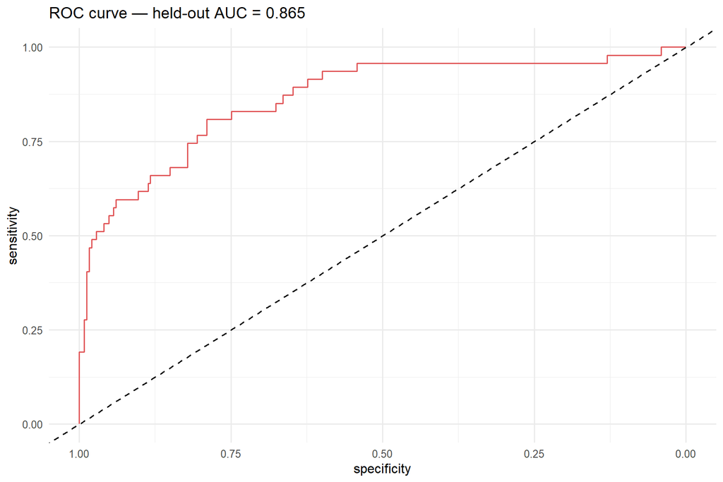

```r
ggroc(roc_obj, color = "#e15759") +
  geom_abline(intercept = 1, slope = 1, linetype = "dashed") +
  labs(title = paste0("ROC curve — held-out AUC = ", round(auc_val, 3)))
```

## Export: full-population scores for the dashboard

The dashboard watch list runs on **this model’s** scores (it is the better-ranked and better-calibrated of the two — see Phase 3c), so the headline metrics and the operational list come from the same place. Scores over the full population are retrospective/in-sample for the training rows; the dashboard labels them accordingly.

```r
all_features <- model_df %>% select(-set, -EmployeeNumber)
logreg_scores <- tibble(
  EmployeeNumber = model_df$EmployeeNumber,
  logreg_score = round(predict(logreg, newdata = all_features,
                               type = "response"), 4)
)
write_csv(logreg_scores, "outputs/logreg-scores.csv")
nrow(logreg_scores)
```

```
## [1] 1470
```

Phase 3b asks whether gradient boosting can beat these numbers; Phase 3c decides what each model is *for*.